# Exercise prediction - a Course Project for Practical Machine Learning

Timo

22 May 2015

## Exploration and feature selection

```r
library(ggplot2);
library(caret);
library(Hmisc);
require(randomForest);
```

Load in the required data set:

```r
set.seed(12345)
pml_training <- read.csv("/Users/timo/Dropbox (Personal)/Practical Machine Learning/project/data/pml-training.csv", na.strings=c("NA","", "#DIV/0!"), header=TRUE)
```

Create a holdout validation set, as we are interested in the out-of-sample error after fitting and training.

```r
inValidation = createDataPartition(pml_training$classe, p = 0.10)[[1]]
validation = pml_training[inValidation,]
trainingWhole =  pml_training[-inValidation,]
```

Remove columns with over 80% NA’s, as it is unlikely that these will help prediction.

```r
trainingWhole <- trainingWhole[,(which((colSums(is.na(pml_training)) / NROW(pml_training)) < .80))]
```

This plot shows that each user performed the 5 variations in alphabetic order. This information is (partially) present in num_window, raw_timestamp_part_1 and raw_timestamp_part_2 but it is best shown by the cvtd_timestamp.

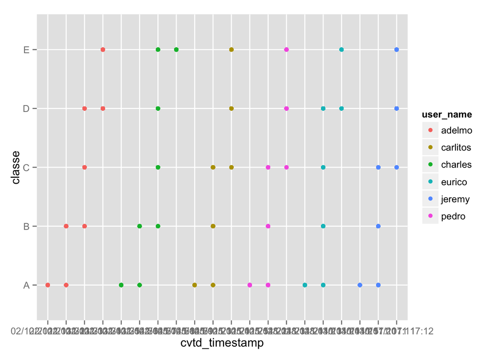

With a simple random forest setup with only 10% of the dataset to train on (initially set for speed) we can already obtain an accuracy of 99% on the test set.

```r
# small test for speed (p=0.10)
inTrain = createDataPartition(trainingWhole$classe, p = 0.10)[[1]]
testTimestampTrain = trainingWhole[inTrain,]
testTimestampTest = trainingWhole[-inTrain,]
testTimestampTrain <- testTimestampTrain[,(names(testTimestampTrain) %in% c("user_name", "raw_timestamp_part_1", "raw_timestamp_part_2", "cvtd_timestamp", "num_window", "classe"))]

trainCtrl <- trainControl(method = "cv",
                     number=5,
                     verboseIter = TRUE,
                     savePredictions = TRUE)

testmodelFit <- train(classe~.,data=testTimestampTrain,method="rf",
                trControl=trainCtrl,
                prox=TRUE,allowParallel=TRUE)
confOverall <- confusionMatrix(testTimestampTest$classe, predict(testmodelFit, testTimestampTest))
# return the accuracy on our test set
print(confOverall$overall)
```

```
##       Accuracy          Kappa  AccuracyLower  AccuracyUpper   AccuracyNull
##      0.9942102      0.9926777      0.9929040      0.9953301      0.2832599
## AccuracyPValue  McnemarPValue
##      0.0000000            NaN
```

```r
# confusionmatrix 5x5
print(round(prop.table(confOverall$table,2),2))
```

```
##           Reference
## Prediction    A    B    C    D    E
##          A 1.00 0.01 0.00 0.00 0.00
##          B 0.00 0.99 0.00 0.00 0.00
##          C 0.00 0.01 0.99 0.01 0.00
##          D 0.00 0.00 0.00 0.99 0.00
##          E 0.00 0.00 0.00 0.00 1.00
```

However, we’re interested in how the actual exercise measurements are related to the classe variable. Thus I remove “user_name” “raw_timestamp_part_1” “raw_timestamp_part_2” “cvtd_timestamp” “num_window” as these will not have any predictive power in future instances, and result in overfitting on our dataset.

```r
# delete the irrelevant columns
trainingWhole <- trainingWhole[,!(names(trainingWhole) %in% c("user_name", "raw_timestamp_part_1", "raw_timestamp_part_2", "cvtd_timestamp", "num_window"))]
```

## Training

Now, split the remaining training set in a testing and training set.

```r
# Usually, we would select p = 0.70, but for speed and easy replicability I've used 0.25 as the training set.
inTrain = createDataPartition(trainingWhole$classe, p = 0.25)[[1]]
training = trainingWhole[inTrain,]
testing =  trainingWhole[-inTrain,]
```

In order to train the model I used cross-validation with 5 folds (initially, also for speed).

```r
trainCtrl <- trainControl(method = "cv",
                     number=5,
                     verboseIter = TRUE,
                     savePredictions = TRUE)

modelFit <- train(classe~.,data=training,method="rf",
                trControl=trainCtrl,
                prox=TRUE,allowParallel=TRUE)
saveRDS(modelFit, "finaltrain_modelfit.rds")

finalconfOverall <- confusionMatrix(testing$classe, predict(modelFit, testing))
# return the accuracy on our test set
print(finalconfOverall)
```

```
## Confusion Matrix and Statistics
##
##           Reference
## Prediction    A    B    C    D    E
##          A 3766    0    0    0    0
##          B    0 2562    0    0    0
##          C    0    1 2308    0    0
##          D    0    0    0 2170    0
##          E    0    0    0    0 2434
##
## Overall Statistics
##
##                Accuracy : 0.9999
##                  95% CI : (0.9996, 1)
##     No Information Rate : 0.2844
##     P-Value [Acc > NIR] : < 2.2e-16
##
##                   Kappa : 0.9999
##  Mcnemar's Test P-Value : NA
##
## Statistics by Class:
##
##                      Class: A Class: B Class: C Class: D Class: E
## Sensitivity            1.0000   0.9996   1.0000   1.0000   1.0000
## Specificity            1.0000   1.0000   0.9999   1.0000   1.0000
## Pos Pred Value         1.0000   1.0000   0.9996   1.0000   1.0000
## Neg Pred Value         1.0000   0.9999   1.0000   1.0000   1.0000
## Prevalence             0.2844   0.1936   0.1743   0.1639   0.1838
## Detection Rate         0.2844   0.1935   0.1743   0.1639   0.1838
## Detection Prevalence   0.2844   0.1935   0.1744   0.1639   0.1838
## Balanced Accuracy      1.0000   0.9998   1.0000   1.0000   1.0000
```

```r
# output a confusionmatrix 5x5
print(round(prop.table(finalconfOverall$table,2),2))
```

```
##           Reference
## Prediction A B C D E
##          A 1 0 0 0 0
##          B 0 1 0 0 0
##          C 0 0 1 0 0
##          D 0 0 0 1 0
##          E 0 0 0 0 1
```

In order to estimate the out-of-sample error we use the previously created validation set.

```r
confValid <- confusionMatrix(validation$classe, predict(modelFit, validation))
# return the accuracy on our test set
print(confValid)
```

```
## Confusion Matrix and Statistics
##
##           Reference
## Prediction   A   B   C   D   E
##          A 558   0   0   0   0
##          B   0 380   0   0   0
##          C   0   0 343   0   0
##          D   0   0   0 322   0
##          E   0   0   0   0 361
##
## Overall Statistics
##
##                Accuracy : 1
##                  95% CI : (0.9981, 1)
##     No Information Rate : 0.2841
##     P-Value [Acc > NIR] : < 2.2e-16
##
##                   Kappa : 1
##  Mcnemar's Test P-Value : NA
##
## Statistics by Class:
##
##                      Class: A Class: B Class: C Class: D Class: E
## Sensitivity            1.0000   1.0000   1.0000    1.000   1.0000
## Specificity            1.0000   1.0000   1.0000    1.000   1.0000
## Pos Pred Value         1.0000   1.0000   1.0000    1.000   1.0000
## Neg Pred Value         1.0000   1.0000   1.0000    1.000   1.0000
## Prevalence             0.2841   0.1935   0.1746    0.164   0.1838
## Detection Rate         0.2841   0.1935   0.1746    0.164   0.1838
## Detection Prevalence   0.2841   0.1935   0.1746    0.164   0.1838
## Balanced Accuracy      1.0000   1.0000   1.0000    1.000   1.0000
```

```r
# output a confusionmatrix 5x5
print(round(prop.table(confValid$table,2),2))
```

```
##           Reference
## Prediction A B C D E
##          A 1 0 0 0 0
##          B 0 1 0 0 0
##          C 0 0 1 0 0
##          D 0 0 0 1 0
##          E 0 0 0 0 1
```